# Homework 4

## Unsupervised Learning

### by: Yasshin Lozano

## Problem 1

Consider the half-moon-shaped structures dataset:

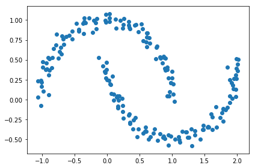

```python
from sklearn.datasets import make_moons
import matplotlib.pyplot as plt


X, y = make_moons(n_samples=200, noise=0.05, random_state=0)
plt.scatter(X[:, 0], X[:, 1])
plt.tight_layout()
plt.show()
```

- Use the `KMeans` class from `scikit-learn`'s `cluster` module to find 2 clusters in this dataset.
- How does the clustering obatined by k-means compare with the one obtained when using DBSCAN? The clustering by KMeans clusters fails compared to the one obtained when using DBSCAN. When using KMeans the clusters are divided roughly along the middle. While DBSCAN seperates the cluster as you would expect, each having their own seperate moon.

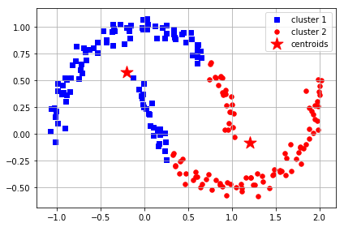

```python
from sklearn.cluster import KMeans
km = KMeans(n_clusters=2,
            init='random',
            n_init=15,
            max_iter=150,
            tol=1e-04,
            random_state=0)

y_km = km.fit_predict(X)

plt.scatter(X[y_km == 0, 0],
            X[y_km == 0, 1],
            s=30,
            c='blue',
            marker='s',
            label='cluster 1')
plt.scatter(X[y_km == 1, 0],
            X[y_km == 1, 1],
            s=30,
            c='red',
            marker='o',
            label='cluster 2')
plt.scatter(km.cluster_centers_[:, 0],
            km.cluster_centers_[:, 1],
            s=250,
            marker='*',
            c='red',
            label='centroids')
plt.legend()
plt.grid()
plt.tight_layout()
plt.show()
```

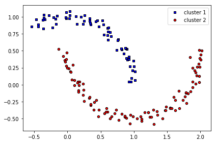

```python
from sklearn.cluster import DBSCAN
from time import time
db = DBSCAN(eps=0.2,min_samples=12,metric='euclidean')
y_db = db.fit_predict(X)

plt.scatter(X[y_db == 0, 0], X[y_db == 0,1],
            c='blue',marker='s', s=20,
            edgecolor='black',
            label='cluster 1')
plt.scatter(X[y_db == 1,0], X[y_db == 1, 1],
           c='red', marker='o', s=20,
           edgecolor='black',
           label='cluster 2')
plt.legend()
plt.tight_layout()
plt.show()
```

## Problem 2

In this problem you will explore an application of k-means in the area of **image processing**.

- Follow the example in `scikit-learn`'s documentation page to check the [Color Quantization using K-Means](http://scikit-learn.org/stable/auto_examples/cluster/plot_color_quantization.html#sphx-glr-auto-examples-cluster-plot-color-quantization-py) implementation.
- Make sure you can understand the code and **add sufficient comments** explaining what each block of code does.
- **Reproduce the example** with this image from the web:

[figure not shown]

In order to read that image you can use include the code below to the original code (make sure to rename any objects for this new example)

```python
from skimage import io
miami = io.imread("https://raw.githubusercontent.com/reisanar/figs/master/miami.jpg")
```

- Try the color quantization approach with `n_colors = 64` and `n_colors = 32`
- Explore the technique with a different image of your choice.

```
Automatically created module for IPython interactive environment
Fitting model on a small sub-sample of the data
done in 0.283s.
Predicting color indices on the full image (k-means)
done in 0.520s.
Predicting color indices on the full image (random)
done in 0.511s.
```

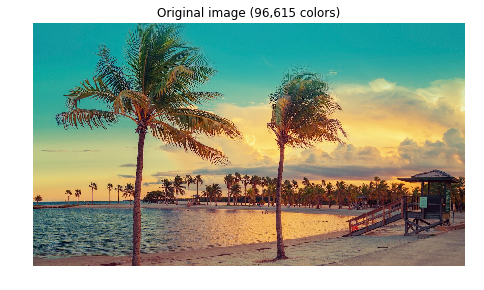

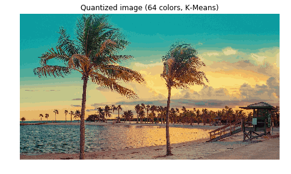

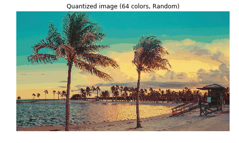

```python
print(__doc__)
import numpy as np
import matplotlib.pyplot as plt
from sklearn.cluster import KMeans

# Computes the minimum distances between one point and a set of points
from sklearn.metrics import pairwise_distances_argmin

# Loads the numpy array of single sample image
from sklearn.datasets import load_sample_image

# Shuffles arrays or sparse matrices in a consistent way
from sklearn.utils import shuffle

# Has multiple time-related functions, but in this instance
# we will be using the function time(). It returns the time in seconds
# since the epoch,point where the time starts, as a flaoting point number.
from time import time

# A variable holding the value of how many colors we will use for the images
n_colors = 64

# Load the Miami Beach photo
# This used to be 'china = load_sample_image("china.jpg")'
# the variable china was being defined to a built-in image
# contained in the image.
# Since the image was imported in the code above this part is
# not needed but I am leaving it here to know that here is where one would laod an image.
miami = miami

# Convert to floats instead of the default 8 bits integer coding. Dividing by
# 255 is important so that plt.imshow behaves works well on float data (need to
# be in the range [0-1])
# dtype is just the data-type for the array. In our case it
# is a float. This is normalizaing the color values in the image
# between 0-255, which are the values for colors.
miami = np.array(miami, dtype=np.float64) / 255

# Loads Image and transform to a 2D numpy array.
# The variable width, height, and depth of the image
# are being assigned to the tuple
# within the miami array and then shaping it
# depth is being set to 3 because a color in RGB is encodded
# as a tuple of 8 bits each. http://lmcaraig.com/color-quantization-using-k-means/
w, h, d = original_shape = tuple(miami.shape)
assert d == 3
image_array = np.reshape(miami, (w * h, d))


print("Fitting model on a small sub-sample of the data")
# The time from the beginning of the epoch begins here
t0 = time()
image_array_sample = shuffle(image_array, random_state=0)[:1000]
# The image is being fit into a KMeans algorithm with the number
# of colors as the number of clusters
kmeans = KMeans(n_clusters=n_colors, random_state=0).fit(image_array_sample)
# The time it took to run this piece of code
print("done in %0.3fs." % (time() - t0))

# Get labels for all points
print("Predicting color indices on the full image (k-means)")
t0 = time()
labels = kmeans.predict(image_array)
print("done in %0.3fs." % (time() - t0))

# The array contaning the color values of the image
# are being shuffled
codebook_random = shuffle(image_array, random_state=0)[:n_colors + 1]
print("Predicting color indices on the full image (random)")
t0 = time()
# The distance between the colors are being randomized
# using the euclidean distance to determine the random color
# The minimum distances between the shuffled image array and
# the first transformed image array
labels_random = pairwise_distances_argmin(codebook_random,
                                          image_array,
                                          axis=0)
print("done in %0.3fs." % (time() - t0))

# The image is being re generated with the different colors
def recreate_image(codebook, labels, w, h):
    """Recreate the (compressed) image from the code book & labels"""
    d = codebook.shape[1]
    image = np.zeros((w, h, d))
    label_idx = 0
    for i in range(w):
        for j in range(h):
            image[i][j] = codebook[labels[label_idx]]
            label_idx += 1
    return image

# Display all results, alongside original image
plt.figure(1)
plt.clf()
ax = plt.axes([0, 0, 1, 1])
plt.axis('off')
plt.title('Original image (96,615 colors)')
plt.imshow(miami)

# Using the KMeans algorithm the colors are now Quantized
# and recreated here
plt.figure(2)
plt.clf()
ax = plt.axes([0, 0, 1, 1])
plt.axis('off')
plt.title('Quantized image (64 colors, K-Means)')
plt.imshow(recreate_image(kmeans.cluster_centers_, labels, w, h))

# Using the shuffle function the colors are Quantized which differs
# from the KMeans
plt.figure(3)
plt.clf()
ax = plt.axes([0, 0, 1, 1])
plt.axis('off')
plt.title('Quantized image (64 colors, Random)')
plt.imshow(recreate_image(codebook_random, labels_random, w, h))
plt.show()
```

```
Automatically created module for IPython interactive environment
Fitting model on a small sub-sample of the data
done in 0.218s.
Predicting color indices on the full image (k-means)
done in 0.352s.
Predicting color indices on the full image (random)
done in 0.346s.
```

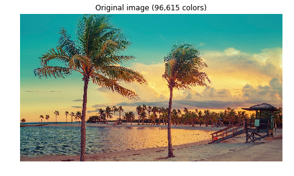

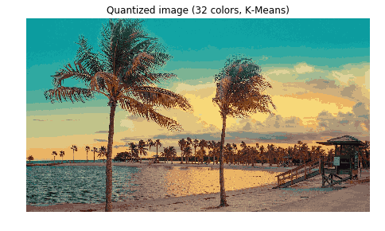

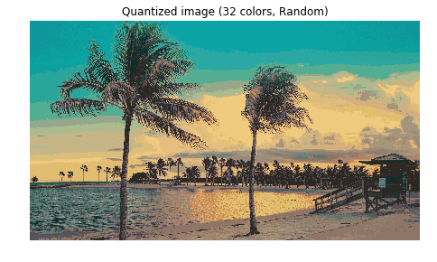

```python
from skimage import io
miami = io.imread("https://raw.githubusercontent.com/reisanar/figs/master/miami.jpg")
print(__doc__)
import numpy as np
import matplotlib.pyplot as plt
from sklearn.cluster import KMeans
from sklearn.metrics import pairwise_distances_argmin
from sklearn.datasets import load_sample_image
from sklearn.utils import shuffle
from time import time

n_colors = 32

# Load the Summer Palace photo
miami = miami

# Convert to floats instead of the default 8 bits integer coding. Dividing by
# 255 is important so that plt.imshow behaves works well on float data (need to
# be in the range [0-1])
miami = np.array(miami, dtype=np.float64) / 255

# Load Image and transform to a 2D numpy array.
w, h, d = original_shape = tuple(miami.shape)
assert d == 3
image_array = np.reshape(miami, (w * h, d))

print("Fitting model on a small sub-sample of the data")
t0 = time()
image_array_sample = shuffle(image_array, random_state=0)[:1000]
kmeans = KMeans(n_clusters=n_colors, random_state=0).fit(image_array_sample)
print("done in %0.3fs." % (time() - t0))

# Get labels for all points
print("Predicting color indices on the full image (k-means)")
t0 = time()
labels = kmeans.predict(image_array)
print("done in %0.3fs." % (time() - t0))


codebook_random = shuffle(image_array, random_state=0)[:n_colors + 1]
print("Predicting color indices on the full image (random)")
t0 = time()
labels_random = pairwise_distances_argmin(codebook_random,
                                          image_array,
                                          axis=0)
print("done in %0.3fs." % (time() - t0))


def recreate_image(codebook, labels, w, h):
    """Recreate the (compressed) image from the code book & labels"""
    d = codebook.shape[1]
    image = np.zeros((w, h, d))
    label_idx = 0
    for i in range(w):
        for j in range(h):
            image[i][j] = codebook[labels[label_idx]]
            label_idx += 1
    return image

# Display all results, alongside original image
plt.figure(1)
plt.clf()
ax = plt.axes([0, 0, 1, 1])
plt.axis('off')
plt.title('Original image (96,615 colors)')
plt.imshow(miami)

plt.figure(2)
plt.clf()
ax = plt.axes([0, 0, 1, 1])
plt.axis('off')
plt.title('Quantized image (32 colors, K-Means)')
plt.imshow(recreate_image(kmeans.cluster_centers_, labels, w, h))

plt.figure(3)
plt.clf()
ax = plt.axes([0, 0, 1, 1])
plt.axis('off')
plt.title('Quantized image (32 colors, Random)')
plt.imshow(recreate_image(codebook_random, labels_random, w, h))
plt.show()
```

## Problem 3

Read the first pages of Chapter 12 *"Implementing a Multilayer Artificial Neural Network from Scratch"* of our textbook, and write a **short summary** of:

(a) Modeling complex functions with artificial neural networks

A neural work was created to find out how the human brain works. Some examples of a deep learning neural network is Google's image search and Google Translate begin able to recognize the contents of an image and recognize text in images for real-time translation into more than 20 languages.

(b) Single-layer neural network recap

The Adaline algorithm consist of a Bias unit, Input values, and weight coefficients to predict the class label. Using the gradient optimization algorithm the weight of the coefficients of the model can be learned. The weight is updated every epoch, the point where the time starts. The Sum of Squared Errors is calculated to find to optimal weights of the model.

(c) Multilayer neural network architecture

The idea of a multilayer perceptron is linking multiple perceptrons to be able to solve non linearly sepreable problem, so multilayer neural network would consist of multiple perceptrons and be considered deep learning. The One-versus-All technique allows one to tackle classification task with an arbitrary number of unique class labels present in the training set.

(d) Activating a neural network via forward propagation

In order to use forward propagation one must first calcualte the activation unit of the hidden layer. An activation unit defines the output of tha node given an input.

Make sure to mention in your summary the concepts and/or ideas that you do not find completely clear.